# Linear Regression, Ridge, and Lasso

# Linear Regression, Ridge, and Lasso

Fit and compare linear regression models with quadratic and sparse penalties. Keep training and test data separate while inspecting coefficient paths and prediction errors, so that improved fit is not confused with improved generalization.

## Run this tour

Run the cells in order with a Python 3 kernel. The first cell locates the companion data and toolbox and installs missing dependencies when needed. All worked examples include their implementation directly in this notebook. Random seeds make comparisons reproducible; you can change them to explore other samples.

```python
# Locate the companion toolbox locally, or fetch it for a standalone/Colab copy.
from pathlib import Path
import importlib.util
import os
import subprocess
import sys

working = Path.cwd()
candidates = [working, working / "python", working.parent / "python"]
python_dir = next((p for p in candidates if (p / "nt_toolbox").is_dir()), None)
if python_dir is None:
    checkout = working / "numerical-tours-support"
    if not checkout.exists():
        subprocess.run(
            [
                "git",
                "clone",
                "--depth",
                "1",
                "--branch",
                "master",
                "https://github.com/gpeyre/numerical-tours.git",
                str(checkout),
            ],
            check=True,
        )
    python_dir = checkout / "python"
os.chdir(python_dir)
if str(python_dir) not in sys.path:
    sys.path.insert(0, str(python_dir))
requirements = python_dir / "requirements.txt"
if any(
    importlib.util.find_spec(name) is None
    for name in [
        "numpy",
        "scipy",
        "matplotlib",
        "skimage",
        "sklearn",
        "pywt",
        "ipywidgets",
        "cvxpy",
        "skfmm",
        "autograd",
        "progressbar",
        "celer",
    ]
):
    subprocess.run(
        [sys.executable, "-m", "pip", "install", "-r", str(requirements)], check=True
    )

import numpy as np
import matplotlib.pyplot as plt

np.random.seed(0)
plt.rcParams.update(
    {
        "figure.figsize": (8, 4),
        "figure.dpi": 100,
        "axes.spines.top": False,
        "axes.spines.right": False,
        "font.size": 11,
        "image.cmap": "gray",
    }
)
%matplotlib inline
```

$\newcommand{\dotp}[2]{\langle #1, #2 \rangle}$ $\newcommand{\enscond}[2]{\lbrace #1, #2 \rbrace}$ $\newcommand{\pd}[2]{ \frac{ \partial #1}{\partial #2} }$ $\newcommand{\umin}[1]{\underset{#1}{\min}\;}$ $\newcommand{\umax}[1]{\underset{#1}{\max}\;}$ $\newcommand{\uargmin}[1]{\underset{#1}{argmin}\;}$ $\newcommand{\norm}[1]{\|#1\|}$ $\newcommand{\abs}[1]{\left|#1\right|}$ $\newcommand{\choice}[1]{ \left\{ \begin{array}{l} #1 \end{array} \right. }$ $\newcommand{\pa}[1]{\left(#1\right)}$ $\newcommand{\diag}[1]{{diag}\left( #1 \right)}$ $\newcommand{\qandq}{\quad\text{and}\quad}$ $\newcommand{\qwhereq}{\quad\text{where}\quad}$ $\newcommand{\qifq}{ \quad \text{if} \quad }$ $\newcommand{\qarrq}{ \quad \Longrightarrow \quad }$ $\newcommand{\ZZ}{\mathbb{Z}}$ $\newcommand{\CC}{\mathbb{C}}$ $\newcommand{\RR}{\mathbb{R}}$ $\newcommand{\EE}{\mathbb{E}}$ $\newcommand{\Zz}{\mathcal{Z}}$ $\newcommand{\Ww}{\mathcal{W}}$ $\newcommand{\Vv}{\mathcal{V}}$ $\newcommand{\Nn}{\mathcal{N}}$ $\newcommand{\NN}{\mathcal{N}}$ $\newcommand{\Hh}{\mathcal{H}}$ $\newcommand{\Bb}{\mathcal{B}}$ $\newcommand{\Ee}{\mathcal{E}}$ $\newcommand{\Cc}{\mathcal{C}}$ $\newcommand{\Gg}{\mathcal{G}}$ $\newcommand{\Ss}{\mathcal{S}}$ $\newcommand{\Pp}{\mathcal{P}}$ $\newcommand{\Ff}{\mathcal{F}}$ $\newcommand{\Xx}{\mathcal{X}}$ $\newcommand{\Mm}{\mathcal{M}}$ $\newcommand{\Ii}{\mathcal{I}}$ $\newcommand{\Dd}{\mathcal{D}}$ $\newcommand{\Ll}{\mathcal{L}}$ $\newcommand{\Tt}{\mathcal{T}}$ $\newcommand{\si}{\sigma}$ $\newcommand{\al}{\alpha}$ $\newcommand{\la}{\lambda}$ $\newcommand{\ga}{\gamma}$ $\newcommand{\Ga}{\Gamma}$ $\newcommand{\La}{\Lambda}$ $\newcommand{\Si}{\Sigma}$ $\newcommand{\be}{\beta}$ $\newcommand{\de}{\delta}$ $\newcommand{\De}{\Delta}$ $\newcommand{\phi}{\varphi}$ $\newcommand{\th}{\theta}$ $\newcommand{\om}{\omega}$ $\newcommand{\Om}{\Omega}$ $\newcommand{\eqdef}{\equiv}$

This tour studies linear regression method in conjunction with regularization. It contrasts ridge regression and the Lasso.

We recommend that after doing this Numerical Tours, you apply it to your own data, for instance using a dataset from [LibSVM](https://www.csie.ntu.edu.tw/~cjlin/libsvmtools/datasets/) or [Kaggle](https://www.kaggle.com/).

*Disclaimer:* these machine learning tours are intended to be overly-simplistic implementations and applications of baseline machine learning methods. For more advanced uses and implementations, we recommend to use a state-of-the-art library, the most well known being [Scikit-Learn](http://scikit-learn.org/).

```python
%matplotlib inline
import numpy as np
import matplotlib.pyplot as plt
```

```python
# Use this code to read from a CSV file.
# import pandas as pd
# U = pd.read_csv('myfile.csv')
```

Usefull functions to convert to a column/row vectors.

```python
#  convert to a column vector
def MakeCol(y):
    return y.reshape(-1, 1)


#  convert to a row vector
def MakeRow(y):
    return y.reshape(1, -1)


# find non zero/true elements
def find(x):
    return np.nonzero(x)[0]
```

## Dataset Loading

We test the method on the prostate dataset in $n=97$ samples with features $x_i \in \RR^p$ in dimension $p=8$. The goal is to predict the price value $y_i \in \RR$.

Load the dataset.

```python
from scipy import io

name = "prostate"
Data = io.loadmat("nt_toolbox/data/ml-" + name)
Ay = Data["A"]
class_names = Data["class_names"]
```

Randomly permute it.

```python
Ay = Ay[np.random.permutation(Ay.shape[0]), :]
```

Separate the features $X$ from the data $y$ to predict information.

```python
A_full = Ay[:, 0:-2]
y_full = MakeCol(Ay[:, -2])
c = MakeCol(Ay[:, -1])
```

Split into training and testing.

```python
I0 = find(c == 1)  # train
I1 = find(c == 0)  # test
n = I0.size
n1 = I1.size
A = A_full[I0, :]
y = y_full[I0]
A1 = A_full[I1, :]
y1 = y_full[I1]
```

$n$ is the total number of samples, $p$ is the dimensionality of the features,

```python
[n, p] = A.shape
print(n, p)
```

```
67 8
```

Normalize the features by the mean and std of the *training* set. This is optional.

```python
mA = A.mean(axis=0)
sA = A.std(axis=0)
A = (A - mA) / sA
A1 = (A1 - mA) / sA
```

```python
m = y.mean()
y = y - m
y1 = y1 - m
```

## Dimenionality Reduction and PCA

In order to display in 2-D or 3-D the data, dimensionality reduction is needed. The simplest method is the principal components analysis (PCA), which performs an orthogonal linear projection on the principal axes (eigenvectors) of the covariance matrix.

Display the covariance matrix of the training set.

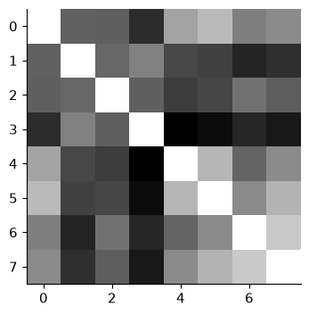

```python
C = A.transpose().dot(A)
plt.imshow(C);
```

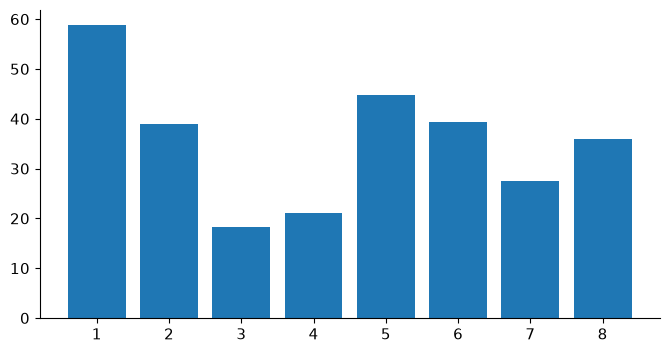

```python
u = A.transpose().dot(y)
plt.clf()
plt.bar(np.arange(1, p + 1), u.flatten())
plt.axis("tight");
```

Compute PCA ortho-basis and the feature in the PCA basis.

```python
U, s, V = np.linalg.svd(A)
Ar = A.dot(V.transpose())
```

Plot sqrt of the eigenvalues.

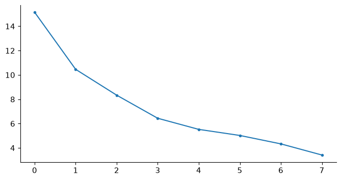

```python
plt.plot(s, ".-");
```

Display the features.

[figure not shown]

```python
pmax = min(p, 8)
k = 0
plt.clf()
for i in np.arange(0, pmax):
    for j in np.arange(0, pmax):
        k = k + 1
        plt.subplot(pmax, pmax, k)
        if i == j:
            plt.hist(A[:, i], 6)
            plt.axis("tight")
        else:
            plt.plot(A[:, j], A[:, i], ".")
        plt.axis("tight")
        if i == 1:
            plt.title(class_names[0][j][0])
        plt.tick_params(axis="x", labelbottom=False)
        plt.tick_params(axis="y", labelleft=False)
```

Display the points cloud of feature vectors in 2-D PCA space.

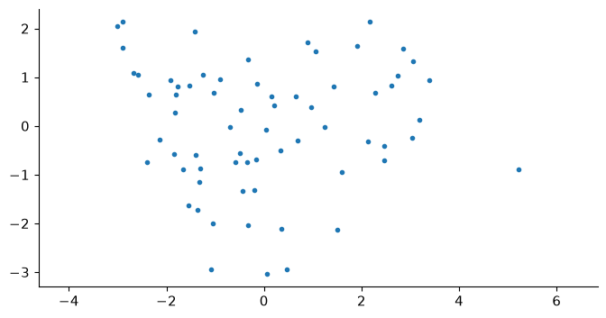

```python
plt.plot(Ar[:, 0], Ar[:, 1], ".")
plt.axis("equal");
```

1D plot of the function to regress along the main eigenvector axes.

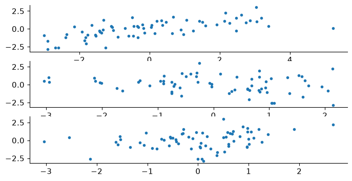

```python
plt.clf()
for i in np.arange(0, 3):
    plt.subplot(3, 1, i + 1)
    plt.plot(Ar[:, i], y, ".")
    plt.axis("tight")
```

## Linear Regression

We look for a linear relationship $ y_i \approx \dotp{x}{a_i} $ written in matrix format $ y= A x $ where the rows of $A \in \RR^{n \times p}$ stores the features $a_i \in \RR^p$.

Since here $n > p$, this is an over-determined system, which can solved in the least square sense $$ \umin{ x } \norm{Ax-y}^2 $$ whose solution is given using the Moore-Penrose pseudo-inverse $$ x = (A^\top A)^{-1} A^\top y $$

Compute the least square solution.

```python
x = np.linalg.solve(A.transpose().dot(A), A.transpose().dot(y))
```

Prediction (along 1st eigenvector).

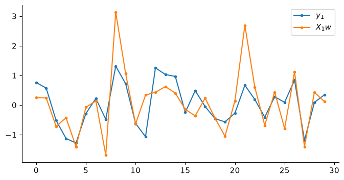

```python
plt.clf()
plt.plot(A1.dot(x), ".-")
plt.plot(y1, ".-")
plt.axis("tight")
plt.legend(("$y_1$", "$X_1 w$"));
```

Mean-square error on testing set.

```python
E = np.linalg.norm(A1.dot(x) - y1) / np.linalg.norm(y1)
print(("Relative prediction error: " + str(E)));
```

```
Relative prediction error: 0.7023447693100113
```

Although this is not an effective method to solve this problem (a more efficient approach is to use for instance conjugate gradient), one can do a gradient descent to minimize the function $$ \min_x f(x) = \frac{1}{2}\norm{A x-y}^2. $$

```python
def f(x):
    return 1 / 2 * np.linalg.norm(A.dot(x) - y) ** 2
```

The gradient of $f$ is $$ \nabla f(x) = A^\top (Ax - y). $$

```python
def Gradf(x):
    return A.transpose().dot(A.dot(x) - y)
```

The maxium step size allowable by the gradient descent is $$ \tau \leq \tau_\max \eqdef \frac{2}{\norm{AA^\top}_{op}} $$ where $\norm{\cdot}_{op}$ is the maximum singular eigenvalue.

```python
tau = 1 / np.linalg.norm(A, 2) ** 2
```

Initialize the algorithm to $x=0$.

```python
x = np.zeros((p, 1))
```

One step of gradient descent reads: $$ x \leftarrow x - \tau \nabla f(x). $$

```python
x = x - tau * Gradf(x)
```

```python
tau_mult = [0.1, 0.5, 1, 1.8]
```

**Worked example 0:** Display the evolution of the training error $f(x)$ as a function of the number of iterations. Test for diffetent values of $\tau$.

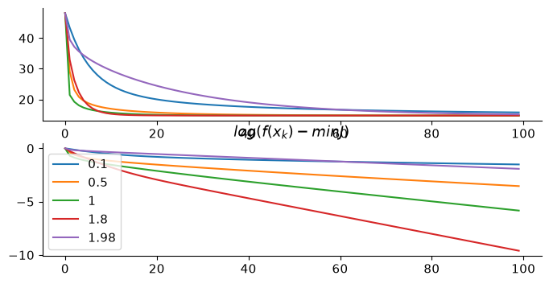

```python
niter = 100
flist = np.zeros((niter, 1))

tau_mult = [0.1, 0.5, 1, 1.8, 1.98]
xopt = np.linalg.solve(A.transpose().dot(A), A.transpose().dot(y))
plt.clf()
fig, (ax1, ax2) = plt.subplots(2, 1)
for itau in np.arange(0, 5):
    tau = tau_mult[itau] / np.linalg.norm(A, 2) ** 2
    x = np.zeros((p, 1))
    for i in np.arange(0, niter):
        flist[i] = f(x)
        x = x - tau * Gradf(x)
    # plt.subplot(2,1,1)
    ax1.plot(flist)
    ax1.axis("tight")
    plt.title("f(x_k)")
    # plt.subplot(2,1,2)
    e = np.log10(flist - f(xopt) + 1e-20)
    ax2.plot(e - e[0], label=str(tau_mult[itau]))
    ax2.axis("tight")
    leg = ax2.legend()
    # ax2.legend( str( tau_mult[itau] ) )
    plt.title("$log(f(x_k)-min J)$")
```

The optimal step size to minimize a quadratic function $\dotp{C w}{w}$ is $$ \tau_{\text{opt}} = \frac{2}{\sigma_\min(C) + \sigma_\max(C)} $$

```python
C = A.transpose().dot(A)
tau_opt = 2 / (np.linalg.norm(C, 2) + np.linalg.norm(C, -2))
print(("Optimal tau = " + str(tau_opt * np.linalg.norm(A, 2) ** 2)) + " / |AA^T|");
```

```
Optimal tau = 1.9032630425437516 / |AA^T|
```

## Stochastic Gradient Method

We use SGD (which is *not* actually a descent algorithm) to minimize the quadratic risk $$ \umin{x} f(x) \eqdef \frac{1}{n} \sum_{i=1}^n f_i(x) = \frac{1}{n} \sum_{i=1}^n \frac{1}{2} ( \dotp{x}{a_i}-y_i )^2 $$ where we used $$ f_i(x) \eqdef \frac{1}{2} ( \dotp{x}{a_i}-y_i )^2$$ The algorithm reads $$ x_{k+1} = x_k - \tau_k \nabla f_{i_k}(x_k)$$ where at each iteration $i_k$ is drawn in $\{1,\ldots,n\}$ uniformly at random.

```python
x = np.zeros((p, 1))
```

Draw $i_k$ are random.

```python
ik = int(np.floor(np.random.rand() * n))
```

Compute $\nabla f_{i_k}(x)$.

```python
gk = (A[ik, :].dot(x) - y[ik]) * A[ik, :].reshape(-1, 1)
```

Set the step size $\tau_k$ (for convergence is should converge to 0) and perform the update.

```python
tauk = 1 / np.linalg.norm(A, 2) ** 2
x = x - tauk * gk
```

**Worked example SGD1:** Test different *fixed* step size $\tau_k=\tau$.

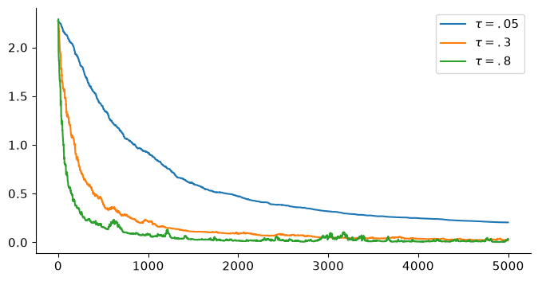

```python
xopt = np.linalg.solve(
    A.transpose().dot(A), A.transpose().dot(y)
)  # least square solution
niter = 5000
flist = np.zeros((niter, 1))
tau_mult = [0.05, 0.3, 0.8]
for itau in np.arange(0, len(tau_mult)):
    tauk = tau_mult[itau] / np.linalg.norm(A, 2) ** 2
    x = np.zeros((p, 1))
    for i in np.arange(0, niter):
        ik = int(np.floor(np.random.rand() * n))
        gk = (A[ik, :].dot(x) - y[ik]) * A[ik, :].reshape(-1, 1)  # stochastic gradient
        # gk = A.transpose().dot( A.dot(x)-y )  # batch gradient
        x = x - tauk * gk
        flist[i] = f(x)
    plt.plot(flist / f(xopt) - 1)
plt.legend(("$\\tau=.05$", "$\\tau=.3$", "$\\tau=.8$"))
```

**Worked example SGD2:** Average on different runs to see the impact of the step size.

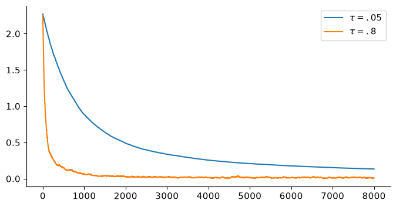

```python
niter = 8000
tau_mult = [0.05, 0.8]
nruns = 10  # number of runs to compute the average performance
for itau in np.arange(0, len(tau_mult)):
    tauk = tau_mult[itau] / np.linalg.norm(A, 2) ** 2
    flist = np.zeros((niter, 1))
    for iruns in np.arange(0, nruns):
        x = np.zeros((p, 1))
        for i in np.arange(0, niter):
            ik = int(np.floor(np.random.rand() * n))
            gk = (A[ik, :].dot(x) - y[ik]) * A[ik, :].reshape(-1, 1)
            x = x - tauk * gk
            flist[i] = flist[i] + f(x)
    plt.plot((flist / nruns) / f(xopt) - 1)
plt.legend(("$\\tau=.05$", "$\\tau=.8$"))
```

**Worked example SGD3:** Use a decaying step size $\tau_k=\frac{\tau_0}{1+k/k_0}$.

```
[0.655136]
```

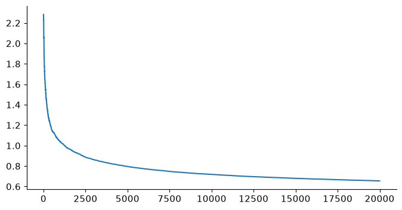

```python
niter = 20000
flist = np.zeros((niter, 1))
x = np.zeros((p, 1))
for i in np.arange(0, niter):
    tauk = 1 / np.linalg.norm(A, 2) ** 2 * 1 / (1 + i / 10)
    ik = int(np.floor(np.random.rand() * n))
    gk = (A[ik, :].dot(x) - y[ik]) * A[ik, :].reshape(-1, 1)
    x = x - tauk * gk
    flist[i] = f(x)
plt.plot(flist / f(xopt) - 1)
print(flist[-1] / f(xopt) - 1)
```

**Worked example SGD4:** Use a decaying step size $\tau_k=\frac{\tau_0}{1+\sqrt{k/k_0}}$ and average the iteration $\frac{1}{K}\sum_{k<K}x_k$.

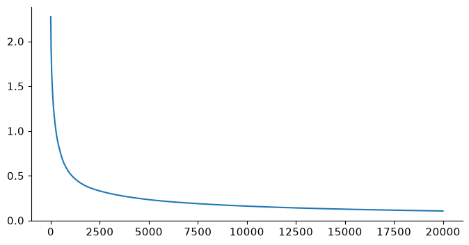

```python
niter = 20000
flist = np.zeros((niter, 1))
x = np.zeros((p, 1))
x1 = np.zeros((p, 1))
for i in np.arange(0, niter):
    tauk = 1 / np.linalg.norm(A, 2) ** 2 * 1 / (1 + np.sqrt(i / 10.0))
    ik = int(np.floor(np.random.rand() * n))
    gk = (A[ik, :].dot(x) - y[ik]) * A[ik, :].reshape(-1, 1)
    x = x - tauk * gk
    x1 = 1 / (i + 1) * x + i / (i + 1) * x1
    flist[i] = f(x1)
plt.plot(flist / f(xopt) - 1);
```

## Ridge Regularization

Regularization is obtained by introducing a penalty. It is often called ridge regression, and is defined as $$ \umin{ x } \norm{Ax-y}^2 + \lambda \norm{x}^2 $$ where $\lambda>0$ is the regularization parameter.

The solution is given using the following equivalent formula $$ x = (A^\top A + \lambda \text{Id}_p )^{-1} A^\top y, $$ $$ x = A^\top ( AA^\top + \lambda \text{Id}_n)^{-1} y, $$ When $p<n$ (which is the case here), the first formula should be prefered.

In contrast, when the dimensionality $p$ of the feature is very large and there is little data, the second is faster. Furthermore, this second expression is generalizable to Kernel Hilbert space setting, corresponding possibly to $p=+\infty$ for some kernels.

```python
Lambda = 0.2 * np.linalg.norm(A) ** 2
x = np.linalg.solve(A.transpose().dot(A) + Lambda * np.eye(p), A.transpose().dot(y))
u = np.linalg.solve(A.dot(A.transpose()) + Lambda * np.eye(n), y)
x1 = A.transpose().dot(u)
print(("Error (should be 0): " + str(np.linalg.norm(x - x1) / np.linalg.norm(x))))
```

```
Error (should be 0): 4.13129918117914e-16
```

**Worked example 1:** Display the evolution of the test error $E$ as a function of $\lambda$.

```
Ridge: 67.90672125664281%
```

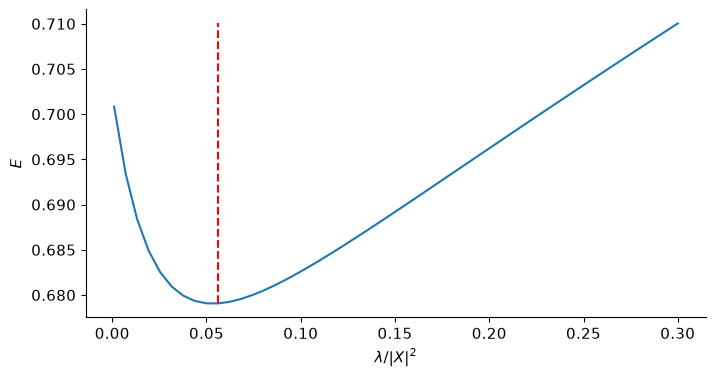

```python
q = 50
lmax = np.linalg.norm(A, 2) ** 2
lambda_list = lmax * np.linspace(0.3, 1e-3, q)
X = np.zeros((p, q))
E = np.zeros((q, 1))
for i in np.arange(0, q):
    Lambda = lambda_list[i]
    x = np.linalg.solve(A.transpose().dot(A) + Lambda * np.eye(p), A.transpose().dot(y))
    X[:, i] = x.flatten()  # bookkeeping
    E[i] = np.linalg.norm(A1.dot(x) - y1) / np.linalg.norm(y1)
# find optimal lambda
i = E.argmin()
lambda0 = lambda_list[i]
xRidge = X[:, i]
print("Ridge: " + str(E.min() * 100) + "%")
# Display error evolution.
plt.clf()
plt.plot(lambda_list / lmax, E)
plt.plot([lambda0 / lmax, lambda0 / lmax], [E.min(), E.max()], "r--")
plt.axis("tight")
plt.xlabel(r"$\lambda/|X|^2$")
plt.ylabel("$E$")
```

**Worked example 2:** Display the regularization path, i.e. the evolution of $w$ as a function of $\lambda$.

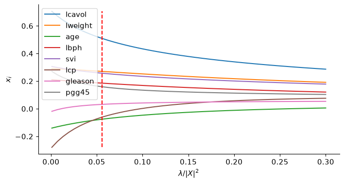

```python
plt.clf()
for i in np.arange(0, p):
    plt.plot(lambda_list / lmax, X[i, :], label=class_names[0][i])
plt.plot(
    [lambda0 / lmax, lambda0 / lmax], [X.flatten().min(), X.flatten().max()], "r--"
)
plt.axis("tight")
plt.xlabel(r"$\lambda/|X|^2$")
plt.ylabel("$x_i$")
plt.legend()
```

## Sparse Regularization

In order to perform feature selection (i.e. select a subsect of the features which are the most predictive), one needs to replace the $\ell^2$ regularization penalty by a sparsity inducing regularizer. The most well known is the $\ell^1$ norm $$ \norm{x}_1 \eqdef \sum_i \abs{x_i} . $$

The energy to minimize is $$ \umin{x} f(x) \eqdef \frac{1}{2}\norm{Ax-y}^2 + \lambda \norm{x}_1. $$

```python
def f(x, Lambda):
    return 1 / 2 * np.linalg.norm(A.dot(x) - y) ** 2 + Lambda * np.linalg.norm(x, 1)
```

The simplest iterative algorithm to perform the minimization is the so-called iterative soft thresholding (ISTA), aka proximal gradient aka forward-backward.

It performs first a gradient step (forward) of the smooth part $\frac{1}{2}\norm{X w-y}^2$ of the functional and then a proximal step (backward) step which account for the $\ell^1$ penalty and induce sparsity. This proximal step is the soft-thresholding operator $$ \Ss_s(x) \eqdef \max( \abs{x}-\lambda,0 ) \text{sign}(x). $$

```python
def Soft(x, s):
    return np.maximum(abs(x) - s, np.zeros(x.shape)) * np.sign(x)
```

The ISTA algorithm reads $$ x_{k+1} \eqdef \Ss_{\la\tau}( x_k - \tau A^\top ( A x_k - y ) ), $$ where, to ensure convergence, the step size should verify $ 0 < \tau < 2/\norm{A}^2 $ where $\norm{A}$ is the operator norm.

Display the soft thresholding operator.

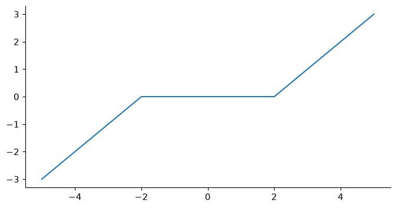

```python
t = np.linspace(-5, 5, 201)
plt.clf()
plt.plot(t, Soft(t, 2))
plt.axis("tight");
```

Descent step size.

```python
tau = 1.5 / np.linalg.norm(A, 2) ** 2
```

Choose a regularization parameter $\la$.

```python
lmax = abs(A.transpose().dot(y)).max()
Lambda = lmax / 10
```

Initialization $w_0$.

```python
x = np.zeros((p, 1))
```

A single ISTA step.

```python
C = A.transpose().dot(A)
u = A.transpose().dot(y)


def ISTA(x, Lambda, tau):
    return Soft(x - tau * (C.dot(x) - u), Lambda * tau)


x = ISTA(x, Lambda, tau)
```

**Worked example 3:** Implement the ISTA algorithm, display the convergence of the energy.

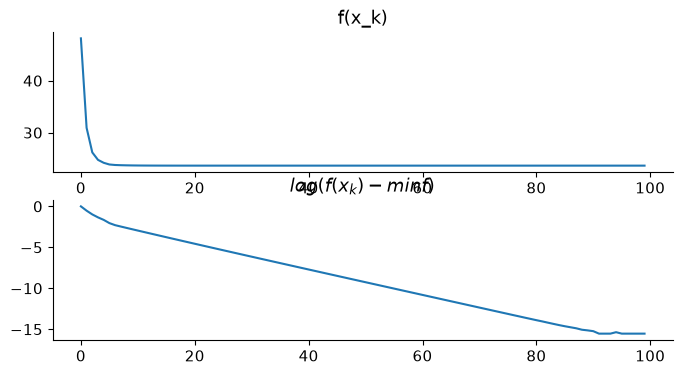

```python
niter = 400
flist = np.zeros((niter, 1))
x = np.zeros((p, 1))
for i in np.arange(0, niter):
    flist[i] = f(x, Lambda)
    x = ISTA(x, Lambda, tau)
ndisp = int(niter / 4)

plt.clf()
plt.subplot(2, 1, 1)
plt.plot(flist[0:ndisp])
plt.axis("tight")
plt.title("f(x_k)")
plt.subplot(2, 1, 2)
e = np.log10(flist[0:ndisp] - flist.min() + 1e-20)
plt.plot(e - e[0])
plt.axis("tight")
plt.title("$log(f(x_k)-min f)$")
```

```
Lasso: 65.42184378732036%
```

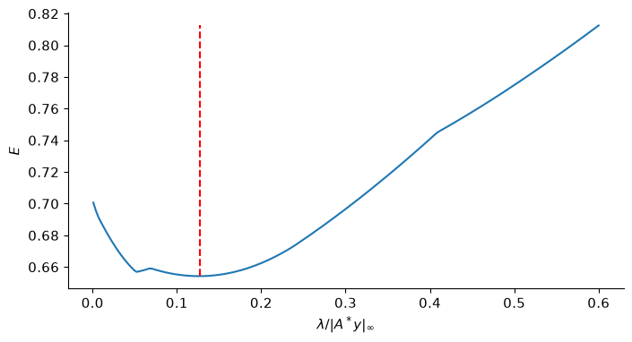

```python
q = 200
lambda_list = lmax * np.linspace(0.6, 1e-3, q)
X = np.zeros((p, q))
E = np.zeros((q, 1))
x = np.zeros((p, 1))
niter = 500
for iq in np.arange(0, q):
    Lambda = lambda_list[iq]
    # ISTA #
    for i in np.arange(0, niter):
        x = ISTA(x, Lambda, tau)
    X[:, iq] = x.flatten()  # bookkeeping
    E[iq] = np.linalg.norm(A1.dot(x) - y1) / np.linalg.norm(y1)
# find optimal Lambda
i = E.argmin()
lambda0 = lambda_list[i]
xSparse = X[:, i]
print("Lasso: " + str(E.min() * 100) + "%")
# Display error evolution.
plt.clf()
plt.plot(lambda_list / lmax, E)
plt.plot([lambda0 / lmax, lambda0 / lmax], [E.min(), E.max()], "r--")
plt.axis("tight")
plt.xlabel(r"$\lambda/|A^* y|_\infty$")
plt.ylabel("$E$")
```

**Worked example 5:** Display the regularization path, i.e. the evolution of $w$ as a function of $\lambda$.

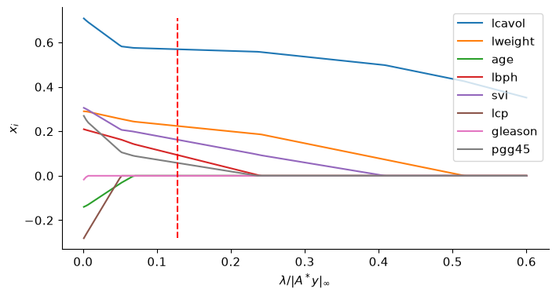

```python
plt.clf()
for i in np.arange(0, p):
    plt.plot(lambda_list / lmax, X[i, :], label=class_names[0][i])
plt.plot(
    [lambda0 / lmax, lambda0 / lmax], [X.flatten().min(), X.flatten().max()], "r--"
)
plt.axis("tight")
plt.xlabel(r"$\lambda/|A^* y|_\infty$")
plt.ylabel("$x_i$")
plt.legend()
```

**Worked example 6:** Compare the optimal weights for ridge and lasso.

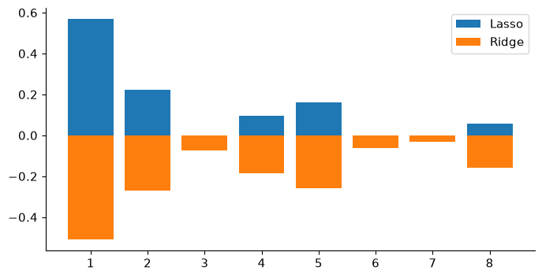

```python
plt.clf()
plt.bar(np.arange(1, p + 1), abs(xSparse))
plt.bar(np.arange(1, p + 1), -abs(xRidge))
plt.legend(("Lasso", "Ridge"))
```

## References and further reading

- Trevor Hastie, Robert Tibshirani, and Jerome Friedman. [The Elements of Statistical Learning](https://hastie.su.domains/ElemStatLearn/). 2009, 2nd ed., Springer. Regression, classification, regularization, and model assessment.
- Gilbert Strang. [Linear Algebra and Learning from Data](https://math.mit.edu/~gs/learningfromdata/). 2019, Wellesley-Cambridge Press. Matrix factorizations, least squares, and low-rank representations.
- Fabian Pedregosa et al.. [Scikit-learn: Machine Learning in Python](https://www.jmlr.org/papers/v12/pedregosa11a.html). 2011, Journal of Machine Learning Research 12, 2825–2830. Practical estimators and reproducible model evaluation.
- Stephen Boyd and Lieven Vandenberghe. [Convex Optimization](https://web.stanford.edu/~boyd/cvxbook/). 2004, Cambridge University Press. Convexity, duality, optimality conditions, and interior-point methods.
- Robert Tibshirani. [Regression Shrinkage and Selection via the Lasso](https://doi.org/10.1111/j.2517-6161.1996.tb02080.x). 1996, Journal of the Royal Statistical Society B 58(1), 267–288. Sparse regression through an absolute-value penalty.